# Methodology

**Tools**

For disk bandwidth test, we use Fio. Fio is short for Flexible IO, a versatile IO workload generator. It was written to benchmark or verify changes to the Linux IO subsystem by Linux developers. Fio is flexible enough to allow detailed workload setups, and it contains the necessary reporting to make sense of the data at completion. Fio is widely used as an industry standard benchmark, stress testing tool, and for IO verification purposes. Fio isn't tied to any OS. It works on any platform from Windows to HP-UX to Android. There are also native IO engines on Linux, Windows, Solaris, etc. This is a key feature to make the measurement repeatable across platforms.

Fio also supports three different types of output formats. The “classic” output is the default which dumps workload statistics at the end of the workload. There's also support for a CSV format called Terse, though that's slowly diminishing in favor of a JSON-based output format. The latter is far more flexible and has the advantage of being simple to parse for people and computers. However, we prefer the terse format since it's available to more versions of FIO since some of the host, user is not able to upgrade FIO version.

**Test Design**

During our measurement, we saw that the bandwidth of random read/write and sequential read/write is very different. To keep the same setting for the test and control the time for each test, we have to consider carefully the size of transfered data, number of parallel threads, number of VMs on one host. If the size is too small, the job finish too quickly, we cannot see the a stable bandwidth of sequential read/write. If the data volume is too big, the random read/write test is take too long to finish. The number of parallel threads also affect a lot on the bandwith (as explained in the result assessment section). We run same number of Virtual Machines. We run Fio on the physical host with different number of Fio threads (from 1 to 16 concurrent threads). Then with the same configuration, we run it from inside different flavors of VM. We also make the comparison with the case that each VM has only one thread but we increase the number of concurrent running VMs on the same host. We also use identical Operating Systems and identical OS' setting across platforms to make sure that the measurement result is reliable.

Our configuration file for Fio has this structure:

```
; sample setting of one thread
[sequential-read]
rw=read
size=(4gb/number_of_parallel_threads)
directory=/home/cloud-user/fiodata
ioengine=libaio
direct=1
iodepth=16
```

Where:

- *rw* defines the kind of disk access pattern: read (sequential reads), write (sequential writes), randread (random reads), randwrite (random writes), or mixed. We specially focus on these only 2 basic access patterns which was happen mostly in the context Big Data world: Sequential read and sequential write. A typical example is the Hadoop File System (HDFS) which has only sequential read and sequential write.
- *size* is the total size of file io for this job. Fio will run until this many bytes of data has been transferred. We choose the total transfer volume to be 4 GBs. This is large enough to avoid many kinds of buffering from the application layet to the OS layer and then to the hardware layer. In facts, some of our initary tests have show that the smaller of size of data volume can cause some very ridiculous results. For example, on some tests we have repoted aggregated throughput of 300MB/s on a single "Seagate Constellation.2 1TB" hard drive while one of professional harddrive benchmarking website claims that the maximum achivable throughput is just about 115 MB/s (http://www.storagereview.com/seagate_constellation2_and_constellation_es2_hard_drive_review). And this is value is more convincing than the 300MB/s one. The data will be divided to threads equally between parallel threads:
  - 1 thread: transfers entire 4 GBs
  - 2 threads: each thread transfer 2 GBs
  - 4 threads: each thread transfer 1 GBs
  - 8 threads: each thread transfer 512 MBs
  - 16 threads: each thread transfer 256 MBs
- *direct I/O* uses the normal filesystem access, but disables buffering and locking operations
- *iodepth* defines the I/O depth of the system. This defines how many io units to keep in flight against the file. The default is 1 for each file defined in this job, can be overridden with a larger value for higher concurrency. We use I/O depth of 1, 16 and 32. Default setting in some of the Linux distribution set I/O depth to 256 or 512.
- *ioengine* is libaio which indicates the application to use AIO subsystem. AIO (Asynchronous Linux IO) help to overlaps processing with I/O Operations. Application can submit (batch) IO without waiting for completion. This benefits physical IO in particular when prefetching data. Besides, It allows to accumulate read or write requests so that the IO subsystem can optimize performance by grouping or reordering the IO request in favor of sequential access and large request. It helps to separate calls for submission and completion indication and pipelines operations to improve throughput. It also helps to improved utilization of CPU and devices.

# Result assessment

Import library to use

```python
# Set figure to display inside notebook
%matplotlib inline
####
import numpy as np
from pandas import *
import pandas as pd
import matplotlib.pyplot as plt
from matplotlib import *
import matplotlib.pylab as pylab
import scipy.stats as td
```

Reading input to pandas

```python
dtresult = pd.read_csv('data/bw16p4g.csv', delimiter=' ', header=None)
dtdata = dtresult[range(1,17)]
dtindex = dtresult[0]
dtdata.index = dtindex.str.replace('T1|T2|T3|T4|T5', '',case=False)
```

```python
# To calculate the average throughput, we first calculate average throughput each thread has in one test, then again take the
# average of 5 tests
avgtpin1test = dtdata.T.mean() # Average throughput of each thread/VM in one test
avgtpin5tests = avgtpin1test.groupby(level=0).mean() # Average throughput of each thread/VM in 5 tests
avgtpin5tests = avgtpin5tests / 1024 # Converting to Megabytes/second
```

```python
# Putting average throughput per thread/VM to vector before plotting
bwsrbf = avgtpin5tests.filter(regex="^SRBFTH").tolist()
bwswbf = avgtpin5tests.filter(regex="^SWBFTH").tolist()

bwsrsvm1c = avgtpin5tests.filter(regex="^SR01VM01CTH").tolist()
bwswsvm1c = avgtpin5tests.filter(regex="^SW01VM01CTH").tolist()
bwsrsvm2c = avgtpin5tests.filter(regex="^SR01VM02CTH").tolist()
bwswsvm2c = avgtpin5tests.filter(regex="^SW01VM02CTH").tolist()
bwsrsvm4c = avgtpin5tests.filter(regex="^SR01VM04CTH").tolist()
bwswsvm4c = avgtpin5tests.filter(regex="^SW01VM04CTH").tolist()
bwsrsvm8c = avgtpin5tests.filter(regex="^SR[0-9]+VM01CTH01").tolist()
bwswsvm8c = avgtpin5tests.filter(regex="^SW01VM08CTH").tolist()
bwsrsvm16c = avgtpin5tests.filter(regex="^SR01VM16CTH").tolist()
bwswsvm16c = avgtpin5tests.filter(regex="^SW01VM16CTH").tolist()

bwsrmvm = avgtpin5tests.filter(regex="^SR[0-9]+VM01CTH01").tolist()
bwswmvm = avgtpin5tests.filter(regex="^SW[0-9]+VM01CTH01").tolist()
```

```python
# Calculate aggregated throughput on each host of each test, then taking the average
aggtpin1test = dtdata.T.sum() # Aggregate throughput on each host in one test
avgaggtpintestgrouped = aggtpin1test.groupby(level=0)
avgaggtpin5tests = avgaggtpintestgrouped.mean() # Then calculate the average of the total throughput through 5 tests
avgaggtpin5tests = avgaggtpin5tests / 1024 # Convert to MB/s
ciaggtpin5tests = avgaggtpintestgrouped.aggregate(lambda x: np.std(x) / np.sqrt(x.count()) * 1.96) # Confident interval of 95%
ciaggtpin5tests = ciaggtpin5tests / 1024 # Convert to same scale with mean
```

```python
# Putting average aggregate throughput to vector before plotting
aggbwsrbf = avgaggtpin5tests.filter(regex="^SRBFTH").tolist()
aggbwswbf = avgaggtpin5tests.filter(regex="^SWBFTH").tolist()
aggbwsrsvm1c = avgaggtpin5tests.filter(regex="^SR01VM01CTH").tolist()
aggbwswsvm1c = avgaggtpin5tests.filter(regex="^SW01VM01CTH").tolist()
aggbwsrsvm2c = avgaggtpin5tests.filter(regex="^SR01VM02CTH").tolist()
aggbwswsvm2c = avgaggtpin5tests.filter(regex="^SW01VM02CTH").tolist()
aggbwsrsvm4c = avgaggtpin5tests.filter(regex="^SR01VM04CTH").tolist()
aggbwswsvm4c = avgaggtpin5tests.filter(regex="^SW01VM04CTH").tolist()
aggbwsrsvm8c = avgaggtpin5tests.filter(regex="^SR01VM08CTH").tolist()
aggbwswsvm8c = avgaggtpin5tests.filter(regex="^SW01VM08CTH").tolist()
aggbwsrsvm16c = avgaggtpin5tests.filter(regex="^SR01VM16CTH").tolist()
aggbwswsvm16c = avgaggtpin5tests.filter(regex="^SW01VM16CTH").tolist()
aggbwsrmvm = avgaggtpin5tests.filter(regex="^SR[0-9]+VM01CTH01").tolist()
aggbwswmvm = avgaggtpin5tests.filter(regex="^SW[0-9]+VM01CTH01").tolist()

# Confidence Interval
ciaggbwsrbf = ciaggtpin5tests.filter(regex="^SRBFTH").tolist()
ciaggbwswbf = ciaggtpin5tests.filter(regex="^SWBFTH").tolist()
ciaggbwsrsvm1c = ciaggtpin5tests.filter(regex="^SR01VM01CTH").tolist()
ciaggbwswsvm1c = ciaggtpin5tests.filter(regex="^SW01VM01CTH").tolist()
ciaggbwsrsvm2c = ciaggtpin5tests.filter(regex="^SR01VM02CTH").tolist()
ciaggbwswsvm2c = ciaggtpin5tests.filter(regex="^SW01VM02CTH").tolist()
ciaggbwsrsvm4c = ciaggtpin5tests.filter(regex="^SR01VM04CTH").tolist()
ciaggbwswsvm4c = ciaggtpin5tests.filter(regex="^SW01VM04CTH").tolist()
ciaggbwsrsvm8c = ciaggtpin5tests.filter(regex="^SR01VM08CTH").tolist()
ciaggbwswsvm8c = ciaggtpin5tests.filter(regex="^SW01VM08CTH").tolist()
ciaggbwsrsvm16c = ciaggtpin5tests.filter(regex="^SR01VM16CTH").tolist()
ciaggbwswsvm16c = ciaggtpin5tests.filter(regex="^SW01VM16CTH").tolist()
ciaggbwsrmvm = ciaggtpin5tests.filter(regex="^SR[0-9]+VM01CTH01").tolist()
ciaggbwswmvm = ciaggtpin5tests.filter(regex="^SW[0-9]+VM01CTH01").tolist()
```

## Throughput

[figure not shown]

```python
x_axis = [1,2,4,8,16]
pylab.rcParams['figure.figsize'] = 12, 8  # change default size of figures
plt.subplot(221)
plt.plot(x_axis, bwsrbf)
plt.plot(x_axis, bwsrsvm1c)
plt.plot(x_axis, bwsrsvm2c)
plt.plot(x_axis, bwsrsvm4c)
plt.plot(x_axis, bwsrsvm8c)
plt.plot(x_axis, bwsrsvm16c)
plt.plot(x_axis, bwsrmvm)
plt.axis([0.9, 16.1, 0, 150])
plt.grid(True)
plt.title('Sequential Read')
pylab.xlabel('concurrent threads/VMs')
pylab.ylabel('throughput (MB/s)')

plt.subplot(222)
plt.plot(x_axis, bwsrbf, label = 'bare-metal total throughput')
plt.plot(x_axis, bwswsvm1c, label = 'SVM-MT avg throughput with 1 core')
plt.plot(x_axis, bwswsvm2c, label = 'SVM-MT avg throughput with 2 cores')
plt.plot(x_axis, bwswsvm4c, label = 'SVM-MT avg throughput with 4 cores')
plt.plot(x_axis, bwswsvm8c, label = 'SVM-MT avg throughput with 8 cores')
plt.plot(x_axis, bwswsvm16c, label = 'SVM-MT avg throughput with 16 cores')
plt.plot(x_axis, bwsrmvm, label = 'MVM-ST avg throughput with 1 core')
plt.axis([0.9, 16.1, 0, 150])
plt.grid(True)
plt.legend(bbox_to_anchor=(1.05, 1), loc=2, borderaxespad=0.)
plt.title('Sequential Write')
pylab.xlabel('concurrent threads/VMs')
#pylab.ylabel('throughput (MB/s)')

plt.subplot(223)
plt.errorbar(x_axis, aggbwsrbf, ciaggbwsrbf)
plt.errorbar(x_axis, aggbwsrsvm1c, ciaggbwsrsvm1c)
plt.errorbar(x_axis, aggbwsrsvm2c, ciaggbwsrsvm2c)
plt.errorbar(x_axis, aggbwsrsvm4c, ciaggbwsrsvm4c)
plt.errorbar(x_axis, aggbwsrsvm8c, ciaggbwsrsvm8c)
plt.errorbar(x_axis, aggbwsrsvm16c, ciaggbwsrsvm16c)
plt.errorbar(x_axis, aggbwsrmvm, ciaggbwsrmvm)
plt.axis([0.9, 16.1, 0, 150])
plt.grid(True)
plt.title('Sequential Read')
pylab.xlabel('concurrent threads/VMs')
pylab.ylabel('throughput (MB/s)')

plt.subplot(224)
plt.errorbar(x_axis, aggbwswbf, ciaggbwswbf, label = 'bare-metal total throughput')
plt.errorbar(x_axis, aggbwswsvm1c, ciaggbwswsvm1c, label = 'total th.put SVM-MT with 1 core')
plt.errorbar(x_axis, aggbwswsvm2c, ciaggbwswsvm2c, label = 'total th.put SVM-MT with 2 cores')
plt.errorbar(x_axis, aggbwswsvm4c, ciaggbwswsvm4c, label = 'total th.put SVM-MT with 4 cores')
plt.errorbar(x_axis, aggbwswsvm8c, ciaggbwswsvm8c, label = 'total th.put SVM-MT with 8 cores')
plt.errorbar(x_axis, aggbwswsvm16c, ciaggbwswsvm16c, label = 'total th.put SVM-MT with 16 cores')
plt.errorbar(x_axis, aggbwswmvm, ciaggbwswmvm, label = 'total th.put MVM-ST')
plt.axis([0.9, 16.1, 0, 150])
plt.grid(True)
plt.title('Sequential Write')
plt.legend(bbox_to_anchor=(1.05, 1), loc=2, borderaxespad=0.)
pylab.xlabel('concurrent threads/VMs')
#pylab.ylabel('throughput (MB/s)')

plt.savefig('throughput16procs.pdf')
```

The two top figures represent the average throughput of each thread in the test, while the bottom ones represent the aggregated throughput from all threads/VMs in the same scenario. With the three scenarios, we have very different behavior. Let me remind you about the three scenarios that we have:

- Bare metal (BM): we have multiple threads concurrently reading data from or writing data to the disk. All the data was read from or written to a directory placed on the same hard drive.
- Single VM with multiple threads (SVM-MT): in this scenario, we have selected 5 different VM flavors (5 different VM's specs). For each of the flavor, we ran the same test with the involvement of 1 to 16 threads. We plotted the performance of each flavor in a distinct line.
- Multiple VMs with a single threads (MVM-ST): in this scenario, we have from 1 to 16 VMs, each VM initiates only one process to read/write data.

The same fixed amount of data was used throughout the test. When there is many concurrent threads or concurrent VMs running in one test, we distributed the data equally to all of them.

For the case of SVM-MT We can easily see that performance of threads inside VM is really low when there are more than two processes active at the same time. We use "active" to prefer to the threads or VMs that are reading/writing data at the time. Some may ask, which one is better "fat" VM or "small" VM? The figures said that, in the context of parallel processes competing for throughput on the same hard drive, "fat" or "small" is not a matter. VM with 1 core is naturally the lowest one, but the VM with 16 cores is not the best one as default. In contrast, its performance is even lower than the VM with 2 cores. However, in gereral SVM-MT form a group with similar performance even the VMs have very different virtualised hardward specs. The aggreated throughput for writing is very good and stable. The throughput of threads inside VM with 8 cores is just a little bit lower than the throughput of bare-metal. The case of low throughput of VM with 16 cores maybe cause by the oversubscription of the host. We do not how many VMs from othe tenant of other users is active at the time. Maybe we can have different result for this case if the host is reserved exclusively for the test.

For bare-metal platform, we can easily see that, for the case of data reading, the overhead is increasing when level of concurency is increasing. This lost in performance may result from the interleaving between processes which causes the head of actuator arm to move more often and inscrease seeking time. We expected that we will see the throughput of thread writing data will be a little lower than reading data. But the results turn out completely unexpected. The aggreated throughput of bare-metal reduce gradually when reading data and lower than the writing test in every case of different concurrency levels. In addition, the writting throughput is very stable and does not show the effection of parallelism.

The most dissapointed point is on the plot of MVM-ST. We see that its behavior is very strange and provide some possibilities that may happens inside:

- We used ssh to start the threads inside each VM in parallel. Due to the handshake of ssh-server and ssh-client at the beginning of the test, our processes may not start at the same time, so the aggregated throughput in this scenario is not the aggregated throughput of parallel process from different VMs but rather the aggregated throughput of mixed serial and parallel processes. One way to have better information on the performance of this scenario is avoiding using ssh and minimizing the communication information of the control program before the "start test" command is executed.
- We have no way to control which disk an instance is executing on. When there are more and more VMs are active, the probability that two or more VMs are executing on different disks is higher. It will turn out that the result for disk stressed test is not correct any more when they are not competeing on the same disk.
- The hypervisor scheduler is not fair, some of the VMs may receive more CPU slot and and finish quicker, then other VMs occupy the "have-just-been" empty faction and finsh quickly after that. It create a series of wave of parallel processed happen during the test, which makes the aggregated throughput from this scenario uncomparable. If it is the case, we have no way but to modify the hypervisor's setting or changing the its internal execution.

## Throughput normalization

*(throughput of bare-metal is used as baseline)*

```python
from __future__ import division # floating point division in Py2x
# for throughput per thread/VM
nml_bwsrbf = [x/y for x,y in zip(bwsrbf,bwsrbf)]
nml_bwswbf = [x/y for x,y in zip(bwswbf,bwswbf)]

nml_bwsrsvm1c = [x/y for x,y in zip(bwsrsvm1c,bwsrbf)]
nml_bwswsvm1c = [x/y for x,y in zip(bwswsvm1c,bwswbf)]
nml_bwsrsvm2c = [x/y for x,y in zip(bwsrsvm2c,bwsrbf)]
nml_bwswsvm2c = [x/y for x,y in zip(bwswsvm2c,bwswbf)]
nml_bwsrsvm4c = [x/y for x,y in zip(bwsrsvm4c,bwsrbf)]
nml_bwswsvm4c = [x/y for x,y in zip(bwswsvm4c,bwswbf)]
nml_bwsrsvm8c = [x/y for x,y in zip(bwsrsvm8c,bwsrbf)]
nml_bwswsvm8c = [x/y for x,y in zip(bwswsvm8c,bwswbf)]
nml_bwsrsvm16c = [x/y for x,y in zip(bwsrsvm16c,bwsrbf)]
nml_bwswsvm16c = [x/y for x,y in zip(bwswsvm16c,bwswbf)]

nml_bwsrmvm = [x/y for x,y in zip(bwsrmvm,bwsrbf)]
nml_bwswmvm = [x/y for x,y in zip(bwswmvm,bwswbf)]

# for aggregated throughput
nml_aggbwsrbf = [x/y for x,y in zip(aggbwsrbf,aggbwsrbf)]
nml_aggbwswbf = [x/y for x,y in zip(aggbwswbf,aggbwswbf)]

nml_aggbwsrsvm1c = [x/y for x,y in zip(aggbwsrsvm1c,aggbwsrbf)]
nml_aggbwswsvm1c = [x/y for x,y in zip(aggbwswsvm1c,aggbwswbf)]
nml_aggbwsrsvm2c = [x/y for x,y in zip(aggbwsrsvm2c,aggbwsrbf)]
nml_aggbwswsvm2c = [x/y for x,y in zip(aggbwswsvm2c,aggbwswbf)]
nml_aggbwsrsvm4c = [x/y for x,y in zip(aggbwsrsvm4c,aggbwsrbf)]
nml_aggbwswsvm4c = [x/y for x,y in zip(aggbwswsvm4c,aggbwswbf)]
nml_aggbwsrsvm8c = [x/y for x,y in zip(aggbwsrsvm8c,aggbwsrbf)]
nml_aggbwswsvm8c = [x/y for x,y in zip(aggbwswsvm8c,aggbwswbf)]
nml_aggbwsrsvm16c = [x/y for x,y in zip(aggbwsrsvm16c,aggbwsrbf)]
nml_aggbwswsvm16c = [x/y for x,y in zip(aggbwswsvm16c,aggbwswbf)]

nml_aggbwsrmvm = [x/y for x,y in zip(aggbwsrmvm,aggbwsrbf)]
nml_aggbwswmvm = [x/y for x,y in zip(aggbwswmvm,aggbwswbf)]
```

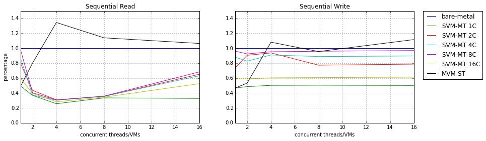

```python
pylab.rcParams['figure.figsize'] = 14, 4  # change default size of figures
x_axis = [1,2,4,8,16]

plt.subplot(121)
plt.plot(x_axis, nml_aggbwsrbf, label = 'bare-metal')
plt.plot(x_axis, nml_aggbwsrsvm1c, label = 'SVM-MT 1C')
plt.plot(x_axis, nml_aggbwsrsvm2c, label = 'SVM-MT 2C')
plt.plot(x_axis, nml_aggbwsrsvm4c, label = 'SVM-MT 4C')
plt.plot(x_axis, nml_aggbwsrsvm8c, label = 'SVM-MT 8C')
plt.plot(x_axis, nml_aggbwsrsvm16c, label = 'SVM-MT 16C')
plt.plot(x_axis, nml_aggbwsrmvm, label = 'MVM-ST')
plt.axis([1, 16, 0, 1.5])
plt.grid(True)
plt.title('Sequential Read')
pylab.xlabel('concurrent threads/VMs')
pylab.ylabel('percentage')

plt.subplot(122)
plt.plot(x_axis, nml_aggbwswbf, label = 'bare-metal')
plt.plot(x_axis, nml_aggbwswsvm1c, label = 'SVM-MT 1C')
plt.plot(x_axis, nml_aggbwswsvm2c, label = 'SVM-MT 2C')
plt.plot(x_axis, nml_aggbwswsvm4c, label = 'SVM-MT 4C')
plt.plot(x_axis, nml_aggbwswsvm8c, label = 'SVM-MT 8C')
plt.plot(x_axis, nml_aggbwswsvm16c, label = 'SVM-MT 16C')
plt.plot(x_axis, nml_aggbwswmvm, label = 'MVM-ST')
plt.axis([1, 16, 0, 1.5])
plt.grid(True)
plt.title('Sequential Write')
plt.legend(bbox_to_anchor=(1.05, 1), loc=2, borderaxespad=0.)
pylab.xlabel('concurrent threads/VMs')
#pylab.ylabel('percentage')

plt.savefig('nml_throughput16procs.pdf')
```

## Jain Fairness Index

```python
jfi = dtdata.T.sum()**2/dtdata.T.count()/(dtdata**2).T.sum() #Calculate Jair Fairness Index for each test
jfigrouped = jfi.groupby(level=0)
jfiavg = jfigrouped.mean() # Calculate JFI average from 5 tests

# for plotting confident interval
# jfistd = jfigrouped.std() # Standard Deviation
cijfi = jfigrouped.aggregate(lambda x: np.std(x) / np.sqrt(x.count()) * 1.96) # Confident interval of 95%

# prepare for plotting
jfisrbf = jfiavg.filter(regex="^SRBFTH").tolist()
jfiswbf = jfiavg.filter(regex="^SWBFTH").tolist()

jfisrsvm1c = jfiavg.filter(regex="^SR01VM01CTH").tolist()
jfiswsvm1c = jfiavg.filter(regex="^SW01VM01CTH").tolist()
jfisrsvm2c = jfiavg.filter(regex="^SR01VM02CTH").tolist()
jfiswsvm2c = jfiavg.filter(regex="^SW01VM02CTH").tolist()
jfisrsvm4c = jfiavg.filter(regex="^SR01VM04CTH").tolist()
jfiswsvm4c = jfiavg.filter(regex="^SW01VM04CTH").tolist()
jfisrsvm8c = jfiavg.filter(regex="^SR01VM08CTH").tolist()
jfiswsvm8c = jfiavg.filter(regex="^SW01VM08CTH").tolist()
jfisrsvm16c = jfiavg.filter(regex="^SR01VM16CTH").tolist()
jfiswsvm16c = jfiavg.filter(regex="^SW01VM16CTH").tolist()

jfisrmvm = jfiavg.filter(regex="^SR[0-9]+VM01CTH01").tolist()
jfiswmvm = jfiavg.filter(regex="^SW[0-9]+VM01CTH01").tolist()


cijfisrbf = cijfi.filter(regex="^SRBFTH").tolist()
cijfiswbf = cijfi.filter(regex="^SWBFTH").tolist()

cijfisrsvm1c = cijfi.filter(regex="^SR01VM01CTH").tolist()
cijfiswsvm1c = cijfi.filter(regex="^SW01VM01CTH").tolist()
cijfisrsvm2c = cijfi.filter(regex="^SR01VM02CTH").tolist()
cijfiswsvm2c = cijfi.filter(regex="^SW01VM02CTH").tolist()
cijfisrsvm4c = cijfi.filter(regex="^SR01VM04CTH").tolist()
cijfiswsvm4c = cijfi.filter(regex="^SW01VM04CTH").tolist()
cijfisrsvm8c = cijfi.filter(regex="^SR01VM08CTH").tolist()
cijfiswsvm8c = cijfi.filter(regex="^SW01VM08CTH").tolist()
cijfisrsvm16c = cijfi.filter(regex="^SR01VM16CTH").tolist()
cijfiswsvm16c = cijfi.filter(regex="^SW01VM16CTH").tolist()

cijfisrmvm = cijfi.filter(regex="^SR[0-9]+VM01CTH01").tolist()
cijfiswmvm = cijfi.filter(regex="^SW[0-9]+VM01CTH01").tolist()
cijfi.filter(regex="^SR[0-9]+VM1CTH01")
```

```
Series([], dtype: float64)
```

[figure not shown]

```python
pylab.rcParams['figure.figsize'] = 14, 4  # change default size of figures
x_axis = [1,2,4,8,16]

plt.subplot(121)
plt.errorbar(x_axis, jfisrbf, cijfisrbf, label = 'bare-metal')
plt.errorbar(x_axis, jfisrsvm1c, cijfisrsvm1c, label = 'SVM-MT 1C')
plt.errorbar(x_axis, jfisrsvm2c, cijfisrsvm2c, label = 'SVM-MT 2C')
plt.errorbar(x_axis, jfisrsvm4c, cijfisrsvm4c, label = 'SVM-MT 4C')
plt.errorbar(x_axis, jfisrsvm8c, cijfisrsvm8c, label = 'SVM-MT 8C')
plt.errorbar(x_axis, jfisrsvm16c, cijfisrsvm16c, label = 'SVM-MT 16C')
plt.errorbar(x_axis, jfisrmvm, cijfisrmvm, label = 'MVM-ST')
plt.axis([0.9, 4.1, 0.85, 1.03])
plt.grid(True)
plt.title('Sequential Read')
plt.xlabel('concurrent threads/VMs')
plt.ylabel('Jain Fairness Index')
plt.xticks(x_axis)

plt.subplot(122)
plt.errorbar(x_axis, jfiswbf, cijfiswbf, label = 'bare-metal')
plt.errorbar(x_axis, jfiswsvm1c, cijfiswsvm1c, label = 'SVM-MT 1C')
plt.errorbar(x_axis, jfiswsvm2c, cijfiswsvm2c, label = 'SVM-MT 2C')
plt.errorbar(x_axis, jfiswsvm4c, cijfiswsvm4c, label = 'SVM-MT 4C')
plt.errorbar(x_axis, jfiswsvm8c, cijfiswsvm8c, label = 'SVM-MT 8C')
plt.errorbar(x_axis, jfiswsvm16c, cijfiswsvm16c, label = 'SVM-MT 16C')
plt.errorbar(x_axis, jfiswmvm, cijfiswmvm, label = 'MVM-ST')
plt.axis([0.9, 4.1, 0.85, 1.03])
plt.grid(True)
plt.title('Sequential Write')
plt.xlabel('concurrent threads/VMs')
plt.legend(bbox_to_anchor=(1.05, 1), loc=2, borderaxespad=0.)
#plt.ylabel('JFI index')
plt.xticks(x_axis)

plt.savefig('jfi16procs.pdf')
```

## CPU Utilization

For CPU utilization, FIO relies on *getrusage()*. *Getrusage()* returns resource usage statistics for the calling thread. The resource usages are returned in the structure pointed to by usage, which has the following form:

```
struct rusage {
    struct timeval ru_utime; /* user CPU time used */
    struct timeval ru_stime; /* system CPU time used */
    ...
    long   ru_minflt;        /* page reclaims (soft page faults) */
    long   ru_majflt;        /* page faults (hard page faults) */
    long   ru_nswap;         /* swaps */
    ...
    long   ru_nvcsw;         /* voluntary context switches */
    long   ru_nivcsw;        /* involuntary context switches */
};
```

and contains inside the *struct*:

- *ru_utime*: This is the total amount of time spent executing in user mode, expressed in a *timeval* structure (seconds plus microseconds).
- *ru_stime*: This is the total amount of time spent executing in kernel mode, expressed in a *timeval* structure (seconds plus microseconds).
- *ru_nvcsw*: The number of times a context switch resulted due to a process voluntarily giving up the processor before its time slice was completed (usually to await availability of a resource).
- *ru_nivcsw*: The number of times a context switch resulted due to a higher priority process becoming runnable or because the current process exceeded its time slice.

FIO reports the CPU utilization for each thread by (*user_time/total_run_time*) and (*system_time/total_run_time*), where:

```
    runtime = ts->total_run_time;
    if (runtime) {
        double runt = (double) runtime;

        usr_cpu = (double) ts->usr_time * 100 / runt;
        sys_cpu = (double) ts->sys_time * 100 / runt;
    } else {
        usr_cpu = 0;
        sys_cpu = 0;
    }
```

In this report, we especially forcus on the the serving time (the time that thread actually uses the CPU) and the waiting time (the time that thread has to wait for the other when its slice is up).

```python
# Remove percentage symbol in csv file first
!sed -i 's/%//g' data/cpuus16p4g.csv
!sed -i 's/%//g' data/cpuks16p4g.csv
```

```python
# Load time spending in user space
cpuusresult = pd.read_csv('data/cpuus16p4g.csv', delimiter=' ', header=None)
cpuusdata = cpuusresult[range(1,17)]
cpuusindex = cpuusresult[0]
cpuusdata.index = cpuusindex.str.replace('T1|T2|T3|T4|T5', '',case=False)
# Load time spending in kernel space
cpuksresult = pd.read_csv('data/cpuks16p4g.csv', delimiter=' ', header=None)
cpuksdata = cpuksresult[range(1,17)]
cpuksindex = cpuksresult[0]
cpuksdata.index = cpuksindex.str.replace('T1|T2|T3|T4|T5', '',case=False)
# Load total runtime of thread
threadruntimeresult = pd.read_csv('data/cpucs16p4g.csv', delimiter=' ', header=None)
threadruntimedata = threadruntimeresult[range(1,17)]
threadruntimeindex = threadruntimeresult[0]
threadruntimedata.index = threadruntimeindex.str.replace('T1|T2|T3|T4|T5', '',case=False)
```

```python
# Calculate duration that thread utilise the CPU
# Real CPU utilisation duration (ms) = (user time (%) + system time (%)) * runtime (ms)
totalcpupercentage = cpuusdata + cpuksdata
totalcputime = totalcpupercentage.mul(threadruntimedata,1) / 100
```

```python
totalcputimehostin1test = totalcputime.T.sum() # Sum of CPU serving time in one test
totalcputime5testsgrouped = totalcputimehostin1test.groupby(level=0)
totalcputimehostavgin5tests = totalcputime5testsgrouped.mean() # Mean of each thread/VM on 5 tests
citct = totalcputime5testsgrouped.aggregate(lambda x: np.std(x) / np.sqrt(x.count()) * 1.96) # Confident interval of 95%
```

```python
threadruntimehostin1test = threadruntimedata.T.sum() # Sum of thread running time in one test
threadruntime5testsgrouped = threadruntimehostin1test.groupby(level=0)
threadruntimehostavgin5tests = threadruntime5testsgrouped.mean() # Mean of each thread/VM on 5 tests
citrt = threadruntime5testsgrouped.aggregate(lambda x: np.std(x) / np.sqrt(x.count()) * 1.96) # Confident interval of 95%
```

```python
# CPU serving time
tctsrbf = totalcputimehostavgin5tests.filter(regex="^SRBFTH").tolist()
tctswbf = totalcputimehostavgin5tests.filter(regex="^SWBFTH").tolist()

tctsrsvm1c = totalcputimehostavgin5tests.filter(regex="^SR01VM01CTH").tolist()
tctswsvm1c = totalcputimehostavgin5tests.filter(regex="^SW01VM01CTH").tolist()
tctsrsvm2c = totalcputimehostavgin5tests.filter(regex="^SR01VM02CTH").tolist()
tctswsvm2c = totalcputimehostavgin5tests.filter(regex="^SW01VM02CTH").tolist()
tctsrsvm4c = totalcputimehostavgin5tests.filter(regex="^SR01VM04CTH").tolist()
tctswsvm4c = totalcputimehostavgin5tests.filter(regex="^SW01VM04CTH").tolist()
tctsrsvm8c = totalcputimehostavgin5tests.filter(regex="^SR01VM08CTH").tolist()
tctswsvm8c = totalcputimehostavgin5tests.filter(regex="^SW01VM08CTH").tolist()
tctsrsvm16c = totalcputimehostavgin5tests.filter(regex="^SR01VM16CTH").tolist()
tctswsvm16c = totalcputimehostavgin5tests.filter(regex="^SW01VM16CTH").tolist()

tctsrmvm = totalcputimehostavgin5tests.filter(regex="^SR[0-9]+VM01CTH01").tolist()
tctswmvm = totalcputimehostavgin5tests.filter(regex="^SW[0-9]+VM01CTH01").tolist()


# Confident interval
citctsrbf = citct.filter(regex="^SRBFTH").tolist()
citctswbf = citct.filter(regex="^SWBFTH").tolist()

citctsrsvm1c = citct.filter(regex="^SR01VM01CTH").tolist()
citctswsvm1c = citct.filter(regex="^SW01VM01CTH").tolist()
citctsrsvm2c = citct.filter(regex="^SR01VM02CTH").tolist()
citctswsvm2c = citct.filter(regex="^SW01VM02CTH").tolist()
citctsrsvm4c = citct.filter(regex="^SR01VM04CTH").tolist()
citctswsvm4c = citct.filter(regex="^SW01VM04CTH").tolist()
citctsrsvm8c = citct.filter(regex="^SR01VM08CTH").tolist()
citctswsvm8c = citct.filter(regex="^SW01VM08CTH").tolist()
citctsrsvm16c = citct.filter(regex="^SR01VM16CTH").tolist()
citctswsvm16c = citct.filter(regex="^SW01VM16CTH").tolist()

citctsrmvm = citct.filter(regex="^SR[0-9]+VM01CTH01").tolist()
citctswmvm = citct.filter(regex="^SW[0-9]+VM01CTH01").tolist()


# Thread running time
trtsrbf = threadruntimehostavgin5tests.filter(regex="^SRBFTH").tolist()
trtswbf = threadruntimehostavgin5tests.filter(regex="^SWBFTH").tolist()

trtsrsvm1c = threadruntimehostavgin5tests.filter(regex="^SR01VM01CTH").tolist()
trtswsvm1c = threadruntimehostavgin5tests.filter(regex="^SW01VM01CTH").tolist()
trtsrsvm2c = threadruntimehostavgin5tests.filter(regex="^SR01VM02CTH").tolist()
trtswsvm2c = threadruntimehostavgin5tests.filter(regex="^SW01VM02CTH").tolist()
trtsrsvm4c = threadruntimehostavgin5tests.filter(regex="^SR01VM04CTH").tolist()
trtswsvm4c = threadruntimehostavgin5tests.filter(regex="^SW01VM04CTH").tolist()
trtsrsvm8c = threadruntimehostavgin5tests.filter(regex="^SR01VM08CTH").tolist()
trtswsvm8c = threadruntimehostavgin5tests.filter(regex="^SW01VM08CTH").tolist()
trtsrsvm16c = threadruntimehostavgin5tests.filter(regex="^SR01VM16CTH").tolist()
trtswsvm16c = threadruntimehostavgin5tests.filter(regex="^SW01VM16CTH").tolist()

trtsrmvm = threadruntimehostavgin5tests.filter(regex="^SR[0-9]+VM01CTH01").tolist()
trtswmvm = threadruntimehostavgin5tests.filter(regex="^SW[0-9]+VM01CTH01").tolist()


# Confident interval
citrtsrbf = citrt.filter(regex="^SRBFTH").tolist()
citrtswbf = citrt.filter(regex="^SWBFTH").tolist()

citrtsrsvm1c = citrt.filter(regex="^SR01VM01CTH").tolist()
citrtswsvm1c = citct.filter(regex="^SW01VM01CTH").tolist()
citrtsrsvm2c = citrt.filter(regex="^SR01VM02CTH").tolist()
citrtswsvm2c = citct.filter(regex="^SW01VM02CTH").tolist()
citrtsrsvm4c = citrt.filter(regex="^SR01VM04CTH").tolist()
citrtswsvm4c = citct.filter(regex="^SW01VM04CTH").tolist()
citrtsrsvm8c = citrt.filter(regex="^SR01VM08CTH").tolist()
citrtswsvm8c = citct.filter(regex="^SW01VM08CTH").tolist()
citrtsrsvm16c = citrt.filter(regex="^SR01VM16CTH").tolist()
citrtswsvm16c = citct.filter(regex="^SW01VM16CTH").tolist()

citrtsrmvm = citrt.filter(regex="^SR[0-9]+VM01CTH01").tolist()
citrtswmvm = citrt.filter(regex="^SW[0-9]+VM01CTH01").tolist()
```

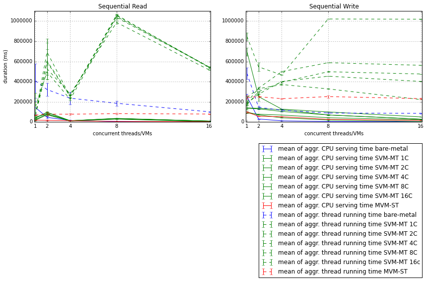

```python
x_axis = [1,2,4,8,16]
pylab.rcParams['figure.figsize'] = 14, 4  # change default size of figures

plt.subplot(121)
plt.errorbar(x_axis, tctsrbf, citctsrbf, color="blue")
plt.errorbar(x_axis, tctsrsvm1c, citctsrsvm1c, color="green")
plt.errorbar(x_axis, tctsrsvm2c, citctsrsvm2c, color="green")
plt.errorbar(x_axis, tctsrsvm4c, citctsrsvm4c, color="green")
plt.errorbar(x_axis, tctsrsvm8c, citctsrsvm8c, color="green")
plt.errorbar(x_axis, tctsrsvm16c, citctsrsvm16c, color="green")
plt.errorbar(x_axis, tctsrmvm, citctsrmvm, color="red")
plt.errorbar(x_axis, trtsrbf, citrtsrbf, ls="dashed", color="blue")
plt.errorbar(x_axis, trtsrsvm1c, citrtsrsvm1c, ls="dashed", color="green")
plt.errorbar(x_axis, trtsrsvm2c, citrtsrsvm2c, ls="dashed", color="green")
plt.errorbar(x_axis, trtsrsvm4c, citrtsrsvm4c, ls="dashed", color="green")
plt.errorbar(x_axis, trtsrsvm8c, citrtsrsvm8c, ls="dashed", color="green")
plt.errorbar(x_axis, trtsrsvm16c, citrtsrsvm16c, ls="dashed", color="green")
plt.errorbar(x_axis, trtsrmvm, citrtsrmvm, ls="dashed", color="red")
plt.axis([0.9, 16.1, 0, 1100000])
plt.grid(True)
plt.title('Sequential Read')
plt.xlabel('concurrent threads/VMs')
plt.ylabel('duration (ms)')
plt.xticks(x_axis)

plt.subplot(122)
plt.errorbar(x_axis, tctswbf, citctswbf, color="blue", label = 'mean of aggr. CPU serving time bare-metal')
plt.errorbar(x_axis, tctswsvm1c, citctswsvm1c, color="green", label = 'mean of aggr. CPU serving time SVM-MT 1C')
plt.errorbar(x_axis, tctswsvm2c, citctswsvm2c, color="green", label = 'mean of aggr. CPU serving time SVM-MT 2C')
plt.errorbar(x_axis, tctswsvm4c, citctswsvm4c, color="green", label = 'mean of aggr. CPU serving time SVM-MT 4C')
plt.errorbar(x_axis, tctswsvm8c, citctswsvm8c, color="green", label = 'mean of aggr. CPU serving time SVM-MT 8C')
plt.errorbar(x_axis, tctswsvm16c, citctswsvm16c, color="green", label = 'mean of aggr. CPU serving time SVM-MT 16C')
plt.errorbar(x_axis, tctswmvm, citctswmvm, color="red", label = 'mean of aggr. CPU serving time MVM-ST')
plt.errorbar(x_axis, trtswbf, citrtswbf, ls="dashed", color="blue", label = 'mean of aggr. thread running time bare-metal')
plt.errorbar(x_axis, trtswsvm1c, citrtswsvm1c, ls="dashed", color="green", label = 'mean of aggr. thread running time SVM-MT 1C')
plt.errorbar(x_axis, trtswsvm2c, citrtswsvm2c, ls="dashed", color="green", label = 'mean of aggr. thread running time SVM-MT 2C')
plt.errorbar(x_axis, trtswsvm4c, citrtswsvm4c, ls="dashed", color="green", label = 'mean of aggr. thread running time SVM-MT 4C')
plt.errorbar(x_axis, trtswsvm8c, citrtswsvm8c, ls="dashed", color="green", label = 'mean of aggr. thread running time SVM-MT 8C')
plt.errorbar(x_axis, trtswsvm16c, citrtswsvm16c, ls="dashed", color="green", label = 'mean of aggr. thread running time SVM-MT 16c')
plt.errorbar(x_axis, trtswmvm, citrtswmvm, ls="dashed", color="red", label = 'mean of aggr. thread running time MVM-ST')
plt.axis([0.9, 16.1, 0, 1100000])
plt.grid(True)
plt.title('Sequential Write')
plt.legend(bbox_to_anchor=(1, -1.4), loc=4, borderaxespad=0.)
plt.xlabel('concurrent threads/VMs')
#plt.ylabel('duration (ms)')
plt.xticks(x_axis)

plt.savefig('CPUutilisation16procs.pdf')
```

In bare-metal environment, the common thought is that sequential write is always slower than sequential read. But in the case of virtualized environment, we can see that sequential write is better than sequential read. The "Sequential Write" CPU utilisation can explain for the better throughput of sequential write operator in virtualized environment: because the thread running time and CPU utilisation of sequential write is less than sequential thread so we have better throughput. (Why??? maybe need to look for the way hypervisor manage the storage)

```python
# for throughput per thread/VM
nml_tctsrbf = [x/y for x,y in zip(tctsrbf,tctsrbf)]
nml_tctswbf = [x/y for x,y in zip(tctswbf,tctswbf)]

nml_tctsrsvm1c = [x/y for x,y in zip(tctsrsvm1c,tctsrbf)]
nml_tctswsvm1c = [x/y for x,y in zip(tctswsvm1c,tctswbf)]
nml_tctsrsvm2c = [x/y for x,y in zip(tctsrsvm2c,tctsrbf)]
nml_tctswsvm2c = [x/y for x,y in zip(tctswsvm2c,tctswbf)]
nml_tctsrsvm4c = [x/y for x,y in zip(tctsrsvm4c,tctsrbf)]
nml_tctswsvm4c = [x/y for x,y in zip(tctswsvm4c,tctswbf)]
nml_tctsrsvm8c = [x/y for x,y in zip(tctsrsvm8c,tctsrbf)]
nml_tctswsvm8c = [x/y for x,y in zip(tctswsvm8c,tctswbf)]
nml_tctsrsvm16c = [x/y for x,y in zip(tctsrsvm16c,tctsrbf)]
nml_tctswsvm16c = [x/y for x,y in zip(tctswsvm16c,tctswbf)]

nml_tctsrmvm = [x/y for x,y in zip(tctsrmvm,tctsrbf)]
nml_tctswmvm = [x/y for x,y in zip(tctswmvm,tctswbf)]


# for throughput per thread/VM
nml_trtsrbf = [x/y for x,y in zip(trtsrbf,trtsrbf)]
nml_trtswbf = [x/y for x,y in zip(trtswbf,trtswbf)]

nml_trtsrsvm1c = [x/y for x,y in zip(trtsrsvm1c,trtsrbf)]
nml_trtswsvm1c = [x/y for x,y in zip(trtswsvm1c,trtswbf)]
nml_trtsrsvm2c = [x/y for x,y in zip(trtsrsvm2c,trtsrbf)]
nml_trtswsvm2c = [x/y for x,y in zip(trtswsvm2c,trtswbf)]
nml_trtsrsvm4c = [x/y for x,y in zip(trtsrsvm4c,trtsrbf)]
nml_trtswsvm4c = [x/y for x,y in zip(trtswsvm4c,trtswbf)]
nml_trtsrsvm8c = [x/y for x,y in zip(trtsrsvm8c,trtsrbf)]
nml_trtswsvm8c = [x/y for x,y in zip(trtswsvm8c,trtswbf)]
nml_trtsrsvm16c = [x/y for x,y in zip(trtsrsvm16c,trtsrbf)]
nml_trtswsvm16c = [x/y for x,y in zip(trtswsvm16c,trtswbf)]

nml_trtsrmvm = [x/y for x,y in zip(trtsrmvm,trtsrbf)]
nml_trtswmvm = [x/y for x,y in zip(trtswmvm,trtswbf)]
```

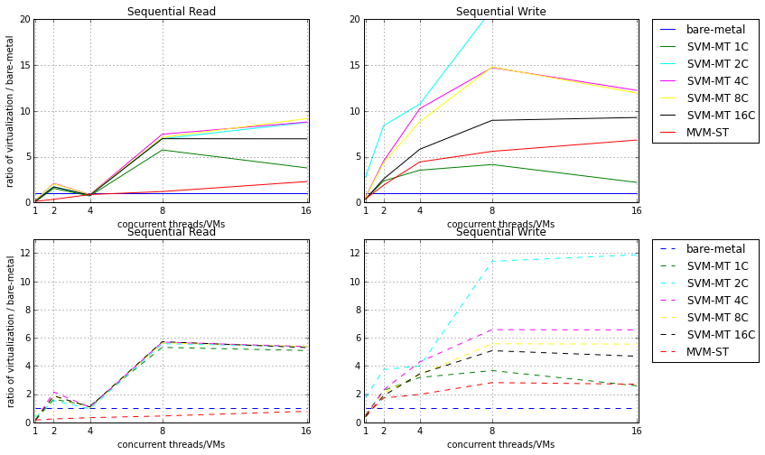

```python
pylab.rcParams['figure.figsize'] = 12, 8  # change default size of figures

plt.subplot(221)
plt.plot(x_axis, nml_tctsrbf, color="blue")
plt.plot(x_axis, nml_tctsrsvm1c, color="green")
plt.plot(x_axis, nml_tctsrsvm2c, color="cyan")
plt.plot(x_axis, nml_tctsrsvm4c, color="magenta")
plt.plot(x_axis, nml_tctsrsvm8c, color="yellow")
plt.plot(x_axis, nml_tctsrsvm16c, color="black")
plt.plot(x_axis, nml_tctsrmvm, color="red")
plt.axis([0.9, 16.1, 0, 20])
plt.grid(True)
plt.title('Sequential Read')
plt.xlabel('concurrent threads/VMs')
plt.ylabel('ratio of virtualization / bare-metal')
plt.xticks(x_axis)

plt.subplot(222)
plt.plot(x_axis, nml_tctswbf, color="blue", label = 'bare-metal')
plt.plot(x_axis, nml_tctswsvm1c, color="green", label = 'SVM-MT 1C')
plt.plot(x_axis, nml_tctswsvm2c, color="cyan", label = 'SVM-MT 2C')
plt.plot(x_axis, nml_tctswsvm4c, color="magenta", label = 'SVM-MT 4C')
plt.plot(x_axis, nml_tctswsvm8c, color="yellow", label = 'SVM-MT 8C')
plt.plot(x_axis, nml_tctswsvm16c, color="black", label = 'SVM-MT 16C')
plt.plot(x_axis, nml_tctswmvm, color="red", label = 'MVM-ST')
plt.axis([0.9, 16.1, 0, 20])
plt.grid(True)
plt.title('Sequential Write')
plt.legend(bbox_to_anchor=(1.05, 1), loc=2, borderaxespad=0.)
plt.xlabel('concurrent threads/VMs')
#plt.ylabel('ratio of virtualization / bare-metal')
plt.xticks(x_axis)

plt.subplot(223)
plt.plot(x_axis, nml_trtsrbf, ls="dashed", color="blue")
plt.plot(x_axis, nml_trtsrsvm1c, ls="dashed", color="green")
plt.plot(x_axis, nml_trtsrsvm2c, ls="dashed", color="cyan")
plt.plot(x_axis, nml_trtsrsvm4c, ls="dashed", color="magenta")
plt.plot(x_axis, nml_trtsrsvm8c, ls="dashed", color="yellow")
plt.plot(x_axis, nml_trtsrsvm16c, ls="dashed", color="black")
plt.plot(x_axis, nml_trtsrmvm, ls="dashed", color="red")
plt.axis([0.9, 16.1, 0, 13])
plt.grid(True)
plt.title('Sequential Read')
plt.xlabel('concurrent threads/VMs')
plt.ylabel('ratio of virtualization / bare-metal')
plt.xticks(x_axis)

plt.subplot(224)
plt.plot(x_axis, nml_trtswbf, ls="dashed", color="blue", label = 'bare-metal')
plt.plot(x_axis, nml_trtswsvm1c, ls="dashed", color="green", label = 'SVM-MT 1C')
plt.plot(x_axis, nml_trtswsvm2c, ls="dashed", color="cyan", label = 'SVM-MT 2C')
plt.plot(x_axis, nml_trtswsvm4c, ls="dashed", color="magenta", label = 'SVM-MT 4C')
plt.plot(x_axis, nml_trtswsvm8c, ls="dashed", color="yellow", label = 'SVM-MT 8C')
plt.plot(x_axis, nml_trtswsvm16c, ls="dashed", color="black", label = 'SVM-MT 16C')
plt.plot(x_axis, nml_trtswmvm, ls="dashed", color="red", label = 'MVM-ST')
plt.axis([0.9, 16.1, 0, 13])
plt.grid(True)
plt.title('Sequential Write')
plt.legend(bbox_to_anchor=(1.05, 1), loc=2, borderaxespad=0.)
plt.xlabel('concurrent threads/VMs')
#plt.ylabel('ratio of virtualization / bare-metal')
plt.xticks(x_axis)

plt.savefig('nml_CPUutilisation16procs.pdf')
```

## Context Switching

```python
cpucsresult = pd.read_csv('data/cpucs16p4g.csv', delimiter=' ', header=None)
cpucsdata = cpucsresult[range(1,17)]
cpucsindex = cpucsresult[0]
cpucsdata.index = cpucsindex.str.replace('T1|T2|T3|T4|T5', '',case=False)
```

```python
cpucshostavgin1test = cpucsdata.T.sum() # Sum of Context Switch of each host in 1 test
cpucshostavgin5tests = cpucshostavgin1test.groupby(level=0).mean() # Mean of total context switch of each host in 5 tests
cics = cpucshostavgin1test.groupby(level=0).aggregate(lambda x: np.std(x) / np.sqrt(x.count()) * 1.96) # Confident interval of 95%
```

```python
cpucssrbf = cpucshostavgin5tests.filter(regex="^SRBFTH").tolist()
cpucsswbf = cpucshostavgin5tests.filter(regex="^SWBFTH").tolist()

cpucssrsvm1c = cpucshostavgin5tests.filter(regex="^SR01VM01CTH").tolist()
cpucsswsvm1c = cpucshostavgin5tests.filter(regex="^SW01VM01CTH").tolist()
cpucssrsvm2c = cpucshostavgin5tests.filter(regex="^SR01VM02CTH").tolist()
cpucsswsvm2c = cpucshostavgin5tests.filter(regex="^SW01VM02CTH").tolist()
cpucssrsvm4c = cpucshostavgin5tests.filter(regex="^SR01VM04CTH").tolist()
cpucsswsvm4c = cpucshostavgin5tests.filter(regex="^SW01VM04CTH").tolist()
cpucssrsvm8c = cpucshostavgin5tests.filter(regex="^SR01VM08CTH").tolist()
cpucsswsvm8c = cpucshostavgin5tests.filter(regex="^SW01VM08CTH").tolist()
cpucssrsvm16c = cpucshostavgin5tests.filter(regex="^SR01VM16CTH").tolist()
cpucsswsvm16c = cpucshostavgin5tests.filter(regex="^SW01VM16CTH").tolist()

cpucssrmvm = cpucshostavgin5tests.filter(regex="^SR[0-9]+VM01CTH01").tolist()
cpucsswmvm = cpucshostavgin5tests.filter(regex="^SW[0-9]+VM01CTH01").tolist()

# Confident interval
cicpucssrbf = cics.filter(regex="^SRBFTH").tolist()
cicpucsswbf = cics.filter(regex="^SWBFTH").tolist()

cicpucssrsvm1c = cics.filter(regex="^SR01VM01CTH").tolist()
cicpucsswsvm1c = cics.filter(regex="^SW01VM01CTH").tolist()
cicpucssrsvm2c = cics.filter(regex="^SR01VM02CTH").tolist()
cicpucsswsvm2c = cics.filter(regex="^SW01VM02CTH").tolist()
cicpucssrsvm4c = cics.filter(regex="^SR01VM04CTH").tolist()
cicpucsswsvm4c = cics.filter(regex="^SW01VM04CTH").tolist()
cicpucssrsvm8c = cics.filter(regex="^SR01VM08CTH").tolist()
cicpucsswsvm8c = cics.filter(regex="^SW01VM08CTH").tolist()
cicpucssrsvm16c = cics.filter(regex="^SR01VM16CTH").tolist()
cicpucsswsvm16c = cics.filter(regex="^SW01VM16CTH").tolist()

cicpucssrmvm = cics.filter(regex="^SR[0-9]+VM01CTH01").tolist()
cicpucsswmvm = cics.filter(regex="^SW[0-9]+VM01CTH01").tolist()
```

[output not shown]

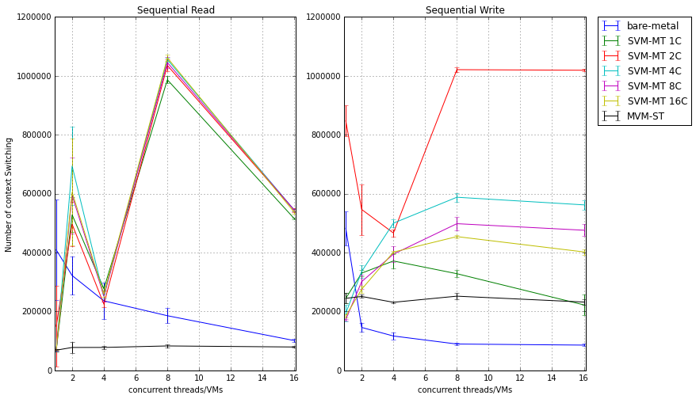

```python
x_axis = [1,2,4,8,16]

plt.subplot(121)
plt.errorbar(x_axis, cpucssrbf, cicpucssrbf, label = 'bare-metal')
plt.errorbar(x_axis, cpucssrsvm1c, cicpucssrsvm1c, label = 'SVM-MT 1C')
plt.errorbar(x_axis, cpucssrsvm2c, cicpucssrsvm2c, label = 'SVM-MT 2C')
plt.errorbar(x_axis, cpucssrsvm4c, cicpucssrsvm4c, label = 'SVM-MT 4C')
plt.errorbar(x_axis, cpucssrsvm8c, cicpucssrsvm8c, label = 'SVM-MT 8C')
plt.errorbar(x_axis, cpucssrsvm16c, cicpucssrsvm16c, label = 'SVM-MT 16C')
plt.errorbar(x_axis, cpucssrmvm, cicpucssrmvm, label = 'MVM-ST')
plt.axis([0.9, 16.1, 0, 1200000])
plt.grid(True)
plt.title('Sequential Read')
pylab.xlabel('concurrent threads/VMs')
pylab.ylabel('Number of context Switching')

plt.subplot(122)
plt.errorbar(x_axis, cpucsswbf, cicpucsswbf, label = 'bare-metal')
plt.errorbar(x_axis, cpucsswsvm1c, cicpucsswsvm1c, label = 'SVM-MT 1C')
plt.errorbar(x_axis, cpucsswsvm2c, cicpucsswsvm2c, label = 'SVM-MT 2C')
plt.errorbar(x_axis, cpucsswsvm4c, cicpucsswsvm4c, label = 'SVM-MT 4C')
plt.errorbar(x_axis, cpucsswsvm8c, cicpucsswsvm8c, label = 'SVM-MT 8C')
plt.errorbar(x_axis, cpucsswsvm16c, cicpucsswsvm16c, label = 'SVM-MT 16C')
plt.errorbar(x_axis, cpucsswmvm, cicpucsswmvm, label = 'MVM-ST')
plt.axis([0.9, 16.1, 0, 1200000])
plt.grid(True)
plt.title('Sequential Write')
plt.legend(bbox_to_anchor=(1.05, 1), loc=2, borderaxespad=0.)
pylab.xlabel('concurrent threads/VMs')
#pylab.ylabel('Number of context Switching')

plt.savefig('nml_CPUContextSwitch16procs.pdf')
```

Other related work have not discussed about context switching in virtualized environment. Since the most spending time task in the hard drive is seeking, or moving the actuator arm to the data location to read/write. The more context switching happens, the more seeking that actuator arm need to move. It will affect directly on the performance of VM.

## IOPS

```python
iopsresult = pd.read_csv('data/dtIOPS.csv', delimiter=' ', header=None)
iopsdata = iopsresult[range(1,21)]
iopsindex = iopsresult[0]
iopsdata.index = iopsindex.str.replace('T1|T2|T3|T4|T5', '',case=False)
```

```python
onehostdata = iopsdata[selectedhost]
```

```python
# To calculate the average throughput, we first calculate average throughput each thread has in one test, then again take the
# average of 5 tests
avgiopsin1test = onehostdata.T.mean() # Average throughput of each thread/VM in one test
avgiopsin5tests = avgiopsin1test.groupby(level=0).mean() # Average throughput of each thread/VM in 5 tests
```

```python
# Putting average throughput per thread/VM to vector before plotting
iopssrbf = avgiopsin5tests.filter(regex="^SRBFTH").tolist()
iopsswbf = avgiopsin5tests.filter(regex="^SWBFTH").tolist()
iopsrrbf = avgiopsin5tests.filter(regex="^RRBFTH").tolist()
iopsrwbf = avgiopsin5tests.filter(regex="^RWBFTH").tolist()
iopssrsvm = avgiopsin5tests.filter(regex="^SR1VMTH").tolist()
iopsswsvm = avgiopsin5tests.filter(regex="^SW1VMTH").tolist()
iopsrrsvm = avgiopsin5tests.filter(regex="^RR1VMTH").tolist()
iopsrwsvm = avgiopsin5tests.filter(regex="^RW1VMTH").tolist()
iopssrmvm = avgiopsin5tests.filter(regex="^SR[1-4]VMTH1").tolist()
iopsswmvm = avgiopsin5tests.filter(regex="^SW[1-4]VMTH1").tolist()
iopsrrmvm = avgiopsin5tests.filter(regex="^RR[1-4]VMTH1").tolist()
iopsrwmvm = avgiopsin5tests.filter(regex="^RW[1-4]VMTH1").tolist()
```

```python
# Calculate aggregated throughput on each host of each test, then taking the average
aggiopsin1test = onehostdata.T.sum() # Aggregate throughput on each host in one test
avgaggiopsintestgrouped = aggiopsin1test.groupby(level=0)
avgaggiopsin5tests = avgaggiopsintestgrouped.mean() # Then calculate the average of the total throughput through 5 tests
ciaggiopsin5tests = avgaggiopsintestgrouped.aggregate(lambda x: np.std(x) / np.sqrt(x.count()) * 1.96) # Confident interval of 95%
```

```python
# Putting average aggregate throughput to vector before plotting
aggiopssrbf = avgaggiopsin5tests.filter(regex="^SRBFTH").tolist()
aggiopsswbf = avgaggiopsin5tests.filter(regex="^SWBFTH").tolist()
aggiopsrrbf = avgaggiopsin5tests.filter(regex="^RRBFTH").tolist()
aggiopsrwbf = avgaggiopsin5tests.filter(regex="^RWBFTH").tolist()
aggiopssrsvm = avgaggiopsin5tests.filter(regex="^SR1VMTH").tolist()
aggiopsswsvm = avgaggiopsin5tests.filter(regex="^SW1VMTH").tolist()
aggiopsrrsvm = avgaggiopsin5tests.filter(regex="^RR1VMTH").tolist()
aggiopsrwsvm = avgaggiopsin5tests.filter(regex="^RW1VMTH").tolist()
aggiopssrmvm = avgaggiopsin5tests.filter(regex="^SR[1-4]VMTH1").tolist()
aggiopsswmvm = avgaggiopsin5tests.filter(regex="^SW[1-4]VMTH1").tolist()
aggiopsrrmvm = avgaggiopsin5tests.filter(regex="^RR[1-4]VMTH1").tolist()
aggiopsrwmvm = avgaggiopsin5tests.filter(regex="^RW[1-4]VMTH1").tolist()

# Confidence Interval
ciaggiopssrbf = ciaggiopsin5tests.filter(regex="^SRBFTH").tolist()
ciaggiopsswbf = ciaggiopsin5tests.filter(regex="^SWBFTH").tolist()
ciaggiopsrrbf = ciaggiopsin5tests.filter(regex="^RRBFTH").tolist()
ciaggiopsrwbf = ciaggiopsin5tests.filter(regex="^RWBFTH").tolist()
ciaggiopssrsvm = ciaggiopsin5tests.filter(regex="^SR1VMTH").tolist()
ciaggiopsswsvm = ciaggiopsin5tests.filter(regex="^SW1VMTH").tolist()
ciaggiopsrrsvm = ciaggiopsin5tests.filter(regex="^RR1VMTH").tolist()
ciaggiopsrwsvm = ciaggiopsin5tests.filter(regex="^RW1VMTH").tolist()
ciaggiopssrmvm = ciaggiopsin5tests.filter(regex="^SR[1-4]VMTH1").tolist()
ciaggiopsswmvm = ciaggiopsin5tests.filter(regex="^SW[1-4]VMTH1").tolist()
ciaggiopsrrmvm = ciaggiopsin5tests.filter(regex="^RR[1-4]VMTH1").tolist()
ciaggiopsrwmvm = ciaggiopsin5tests.filter(regex="^RW[1-4]VMTH1").tolist()
```

```python
x_axis = [1,2,3,4]

plt.subplot(241)
plt.plot(x_axis, iopssrbf, x_axis, iopssrsvm, x_axis, iopssrmvm)
plt.axis([0.9, 4.1, 0, 40000])
plt.grid(True)
plt.title('Sequential Read')
pylab.xlabel('concurrent threads/VMs')
pylab.ylabel('IOPS')

plt.subplot(242)
plt.plot(x_axis, iopsswbf, x_axis, iopsswsvm, x_axis, iopsswmvm)
plt.axis([0.9, 4.1, 0, 40000])
plt.grid(True)
plt.title('Sequential Write')
pylab.xlabel('concurrent threads/VMs')
pylab.ylabel('IOPS')

plt.subplot(243)
plt.plot(x_axis, iopsrrbf, x_axis, iopsrrsvm, x_axis, iopsrrmvm)
plt.axis([0.9, 4.1, 0, 40000])
plt.grid(True)
plt.title('Random Read')
pylab.xlabel('concurrent threads/VMs')
pylab.ylabel('IOPS)')

plt.subplot(244)
plt.plot(x_axis, iopsrwbf, label = 'bare-metal IO request')
plt.plot(x_axis, iopsrwsvm, label = 'Avg. IO requests per thread SVM-MT')
plt.plot(x_axis, iopsrwmvm, label = 'Avg. IO requests per VM MVM-ST')
plt.axis([0.9, 4.1, 0, 40000])
plt.grid(True)
plt.title('Random Write')
plt.legend(bbox_to_anchor=(1.05, 1), loc=2, borderaxespad=0.)
pylab.xlabel('concurrent threads/VMs')
pylab.ylabel('IOPS')

plt.subplot(245)
plt.errorbar(x_axis, aggiopssrbf, ciaggiopssrbf)
plt.errorbar(x_axis, aggiopssrsvm, ciaggiopssrsvm)
plt.errorbar(x_axis, aggiopssrmvm, ciaggiopssrmvm)
plt.axis([0.9, 4.1, 0, 40000])
plt.grid(True)
plt.title('Sequential Read')
pylab.xlabel('concurrent threads/VMs')
pylab.ylabel('IOPS')

plt.subplot(246)
plt.errorbar(x_axis, aggiopsswbf, ciaggiopsswbf)
plt.errorbar(x_axis, aggiopsswsvm, ciaggiopsswsvm)
plt.errorbar(x_axis, aggiopsswmvm, ciaggiopsswmvm)
plt.axis([0.9, 4.1, 0, 40000])
plt.grid(True)
plt.title('Sequential Write')
pylab.xlabel('concurrent threads/VMs')
pylab.ylabel('IOPS')

plt.subplot(247)
plt.errorbar(x_axis, aggiopsrrbf, ciaggiopsrrbf)
plt.errorbar(x_axis, aggiopsrrsvm, ciaggiopsrrsvm)
plt.errorbar(x_axis, aggiopsrrmvm, ciaggiopsrrmvm)
plt.axis([0.9, 4.1, 0, 40000])
plt.grid(True)
plt.title('Random Read')
pylab.xlabel('concurrent threads/VMs')
pylab.ylabel('IOPS')

plt.subplot(248)
plt.errorbar(x_axis, aggiopsrwbf, ciaggiopsrwbf, label = 'bare-metal IO requests')
plt.errorbar(x_axis, aggiopsrwsvm, ciaggiopsrwsvm, label = 'avg. agg. IOPS SVM-MT')
plt.errorbar(x_axis, aggiopsrwmvm, ciaggiopsrwmvm, label = 'avg. agg. IOPS MVM-ST')
plt.axis([0.9, 4.1, 0, 40000])
plt.grid(True)
plt.title('Random Write')
plt.legend(bbox_to_anchor=(1.05, 1), loc=2, borderaxespad=0.)
pylab.xlabel('concurrent threads/VMs')
pylab.ylabel('IOPS')
```

[output not shown]

Input-Output Per Second (IOPS) – a measure of how many read and write commands a disk can complete in a second Note: Bare-metal doesn't give the IOPS measurement. The input data was wrong. The data for VM cases are also very ridiculous. Some articals point out that theorial maximum IOPS for an HDD with 7200rpm just about 189, and actual value is around 169.

**Read more**: Storage Basics:

- http://vmtoday.com/2009/12/storage-basics-part-i-intro/
- http://vmtoday.com/2009/12/storage-basics-part-ii-iops/
- http://vmtoday.com/2010/01/storage-basics-part-iii-raid/
- http://vmtoday.com/2010/01/storage-basics-part-iv-interface/
- http://vmtoday.com/2010/03/storage-basics-part-v-controllers-cache-and-coalescing/
- http://vmtoday.com/2010/04/storage-basics-part-vi-storage-workload-characterization/
- http://don.blogs.smugmug.com/2007/10/08/hdd-iops-limiting-factor-seek-or-rpm/
- http://www.sqlservercentral.com/blogs/sqlmanofmystery/archive/2009/12/07/fundamentals-of-storage-systems-raid-an-introduction.aspx
- http://blog.aarondelp.com/2009/10/its-now-all-about-iops.html